# Assignment1

Tianran Zhang

5/24/2020

## 1.

**Coronary bypass surgery is a major surgical procedure that is often performed on older adults with heart conditions. Recovery time from the surgery varies, and is potentially associated with age. The state regulations and hospital practices on the procedure also vary, and may affect the recovery time.**

### EDA

Take a look at the data

```r
recovery <- read.csv("recovery.csv")

# Clean the column name of the data
recovery <- clean_names(recovery)

# Look at the structure of the data
str(recovery)
```

```
## 'data.frame':    120 obs. of  5 variables:
##  $ paitent_id        : int  1 2 3 4 5 6 7 8 9 10 ...
##  $ hospital          : Factor w/ 12 levels "DH","HH","HUMC",..: 7 7 7 7 7 7 8 8 8 8 ...
##  $ state             : Factor w/ 3 levels "CT","NJ","NY": 3 3 3 3 3 3 3 3 3 3 ...
##  $ age_years         : int  72 81 77 78 88 80 76 82 82 77 ...
##  $ recovery_time_days: int  71 66 67 57 66 68 62 60 67 64 ...
```

```r
# Correct variable types
recovery$paitent_id <- as.factor(recovery$paitent_id)

#Any missing data or outliers
sum(is.na(recovery))
```

```
## [1] 0
```

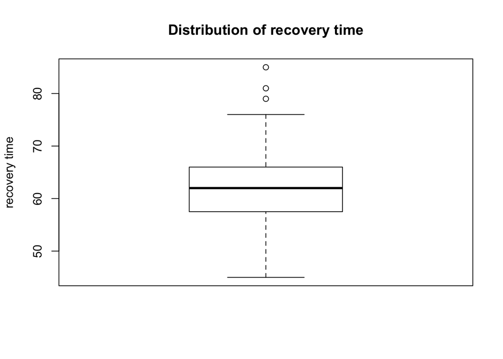

```r
boxplot(recovery$recovery_time_days, ylab = "recovery time",
        main = "Distribution of recovery time")
```

There is no missing values but three outliers in our dataset.

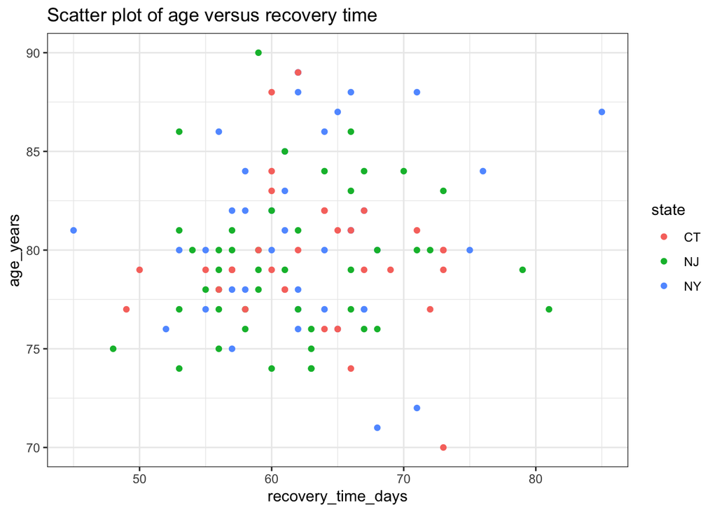

```r
# Plot data
ggplot(data = recovery) +
  geom_point(aes(x = recovery_time_days, y = age_years, col = state)) +
  ggtitle("Scatter plot of age versus recovery time") +
  theme_bw()
```

The scatter plot above shows no clear trends between recovery time and age.

### Description of Model building

The outcome of interest is the recovery time from the Coronary bypass surgery (days). It is potentially associated with age. The state regulations and hospital practices on the procedure also vary, and may affect the recovery time. So, In the model, I set age as the fixed effect, state as a random effect, and hospital as a random effect nested with state.
$$Y_{ijk} = \beta_0 + \beta_1Age_{ijk} + a_j + b_{j(k)} + \epsilon_{ijk}$$
Where $Y_{ijk}$ represents the recovery time of patient i in hospital k, state j;
$\beta_0$ represents the overall mean; $\beta_1$ represents the fixed effect of age for patient i in hospital k, state j;
$a_j\sim N(0, \sigma_a^2)$ represents the random effect of state j;
$b_{j(k)}\sim N(0, \sigma_b^2)$ represents the random effect of hospital k nested within state j;
$\epsilon_{ijk} \sim N(0, \sigma_e^2)$ represents error term for patient i in hospital k, state j.

Now fit this model and check for model assumptions.

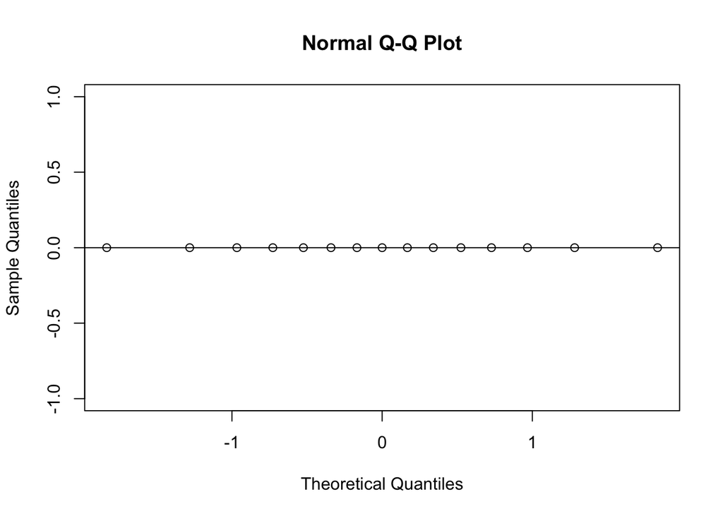

```r
# Model with fixed effect of age, random effect of state, and random effect of hospital nested with state.
a <- lmer(recovery_time_days ~ age_years + (1|state) + (1|state: hospital),
          data = recovery)


#Check the normality of random effects
reffects <- unlist(ranef(a))
qqnorm(reffects)
qqline(reffects)
```

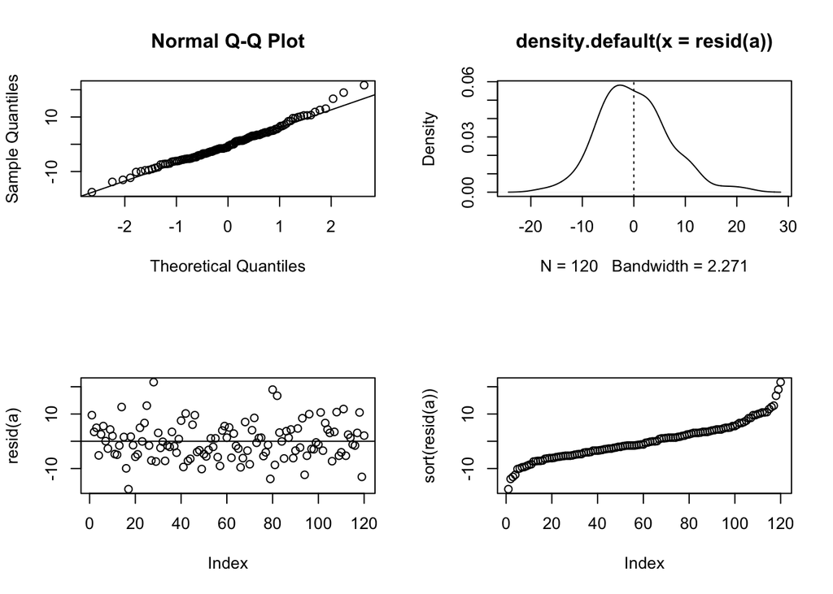

```r
# Check model assumptions:
par(mfrow = c(2, 2))
qqnorm(resid(a))
qqline(resid(a))

plot(density(resid(a)))
abline(v = 0, lty = 3)

# Homoskedasticity
plot(resid(a))
abline(h = 0)
# Outliers
plot(sort(resid(a)))
```

```r
shapiro.test(resid(a))
```

```
##
##  Shapiro-Wilk normality test
##
## data:  resid(a)
## W = 0.98538, p-value = 0.2224
```

### Description of analyses

Take a look at the summary of the fitted model.

```r
summary(a)
```

```
## Linear mixed model fit by REML. t-tests use Satterthwaite's method [
## lmerModLmerTest]
## Formula: recovery_time_days ~ age_years + (1 | state) + (1 | state:hospital)
##    Data: recovery
##
## REML criterion at convergence: 799.9
##
## Scaled residuals:
##     Min      1Q  Median      3Q     Max
## -2.5772 -0.7085 -0.1260  0.5855  3.1865
##
## Random effects:
##  Groups         Name        Variance Std.Dev.
##  state:hospital (Intercept)  0.00    0.000
##  state          (Intercept)  0.00    0.000
##  Residual                   46.36    6.809
## Number of obs: 120, groups:  state:hospital, 12; state, 3
##
## Fixed effects:
##             Estimate Std. Error       df t value Pr(>|t|)
## (Intercept)  52.3254    12.4155 118.0000   4.215 4.93e-05 ***
## age_years     0.1262     0.1552 118.0000   0.813    0.418
## ---
## Signif. codes:  0 '***' 0.001 '**' 0.01 '*' 0.05 '.' 0.1 ' ' 1
##
## Correlation of Fixed Effects:
##           (Intr)
## age_years -0.999
## convergence code: 0
## boundary (singular) fit: see ?isSingular
```

Fitted model:
$$Y_{ijk} = 52.325 + 0.126Age_{ijk} + a_j + b_{j(k)} + \epsilon_{ijk}$$
Where $Y_{ijk}$ represents the recovery time of patient i in hospital k, state j;
$a_j\sim N(0, 0)$;
$b_{j(k)}\sim N(0, 0)$;
$\epsilon_{ijk} \sim N(0, 46.4)$.
At the 5% significance level, there was no statistically significant association between age and recovery time (p = 0.42).
The variances of the random effect of state and hospital are both 0. It seems like we do not need to use the random effect model. So, I tried the linear model with only fixed effect.
$$Y_i = \beta_0 + \beta_1Age_i + \epsilon_i$$
Where $Y_{i}$ represents the recovery time of patient i;
$\beta_0$ represents the intercept;
$\beta_1$ represents the fixed effect of age for patient i (slope);
$\epsilon_{ijk} \sim N(0, \sigma_e^2)$ represents the error term.

```r
a_lm <- lm(recovery_time_days ~ age_years, data = recovery)

# Compare the two models
anova(a, a_lm)
```

```
## Data: recovery
## Models:
## a_lm: recovery_time_days ~ age_years
## a: recovery_time_days ~ age_years + (1 | state) + (1 | state:hospital)
##      Df   AIC    BIC  logLik deviance Chisq Chi Df Pr(>Chisq)
## a_lm  3 804.9 813.26 -399.45    798.9
## a     5 808.9 822.84 -399.45    798.9     0      2          1
```

```r
summary(a_lm)
```

```
##
## Call:
## lm(formula = recovery_time_days ~ age_years, data = recovery)
##
## Residuals:
##      Min       1Q   Median       3Q      Max
## -17.5471  -4.8239  -0.8579   3.9868  21.6957
##
## Coefficients:
##             Estimate Std. Error t value Pr(>|t|)
## (Intercept)  52.3254    12.4155   4.215 4.93e-05 ***
## age_years     0.1262     0.1552   0.813    0.418
## ---
## Signif. codes:  0 '***' 0.001 '**' 0.01 '*' 0.05 '.' 0.1 ' ' 1
##
## Residual standard error: 6.809 on 118 degrees of freedom
## Multiple R-squared:  0.005572,   Adjusted R-squared:  -0.002855
## F-statistic: 0.6612 on 1 and 118 DF,  p-value: 0.4178
```

It seems there is no significant difference between these two models(p = 1). The fitted model is: $Y_i = 52.325 + 0.126Age_i$. At the 5% significance level, there was no statistically significant association between age and recovery time (p = 0.42).

### Conclusions

We were interested in looking at the effect of age on recovery time from the surgery after controlling for the variation in hospital and state. Linear mix effect regression model with age as the fixed effect, state and hospital nested within state are the random effects was conducted to estimate the effect of age on recovery time. ANOVA comparisons were used in model selection. Linear regression model with only fixed effect is also conducted. The two models do not have significant difference. At the 5% significance level, there was no statistically significant association between age and recovery time (p = 0.42).

## 2.

**Some Type II Diabetes patients are going through negative life changes, which is likely to raise their blood sugar level.**

### EDA

```r
a1cq <- read.csv("A1Cq.csv")

# Look at the structure of the data
# str(a1cq)

# Correct variable types
a1cq$Patient <- factor(a1cq$Patient)
# head(a1cq)
```

```r
#Any missing data or outliers
sum(is.na(a1cq))
```

```
## [1] 0
```

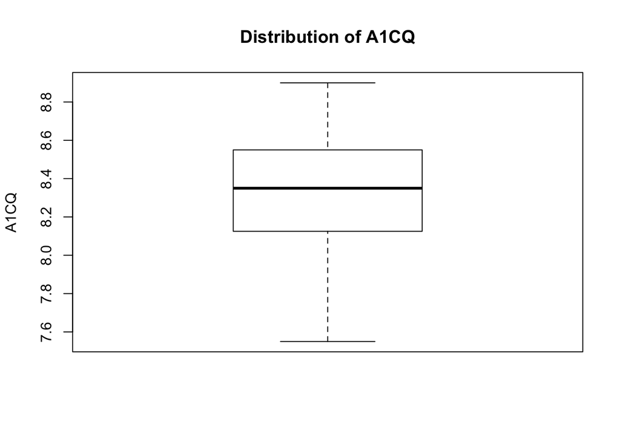

```r
boxplot(a1cq$A1C, ylab = "A1CQ", main = "Distribution of A1CQ")
```

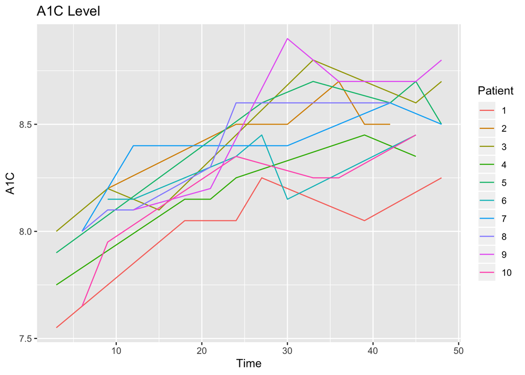

```r
# Visualize Data
ggplot(data = a1cq, aes(x = Time, y = A1C, group = Patient,
                        color = Patient)) +
  geom_line() +
  ggtitle("A1C Level")
```

```r
  theme_bw()
```

[output not shown]

[output cut: 348 more lines]

[output not shown]

There is no missing values or obvious outlier in the dataset.

### Description of model building

Now fit this model and check for model assumptions.

```r
a1cq$Time_2 <- a1cq$Time^2

# Build a quadratic growth model based using random effects.
# Regression model with time and time square as random slopes, without random intercept
b <- lmer(A1C ~ 1 + Time + Time_2 + (1|Patient) + (0 + Time|Patient) + (0 + Time_2|Patient), data = a1cq)
# Regression model with time and time square as random slopes, with random intercept
b1 <- lmer(A1C ~ 1 + Time + Time_2 + (1|Patient) + (1 + Time|Patient) + (1 + Time_2|Patient), data = a1cq)
anova(b, b1)
```

```
## Data: a1cq
## Models:
## b: A1C ~ 1 + Time + Time_2 + (1 | Patient) + (0 + Time | Patient) +
## b:     (0 + Time_2 | Patient)
## b1: A1C ~ 1 + Time + Time_2 + (1 | Patient) + (1 + Time | Patient) +
## b1:     (1 + Time_2 | Patient)
##    Df     AIC     BIC logLik deviance Chisq Chi Df Pr(>Chisq)
## b   7 -48.627 -33.966 31.313  -62.627
## b1 11 -40.079 -17.041 31.040  -62.079     0      4          1
```

It seems like model b is better than model b1 with a lower AIC of -48.6.

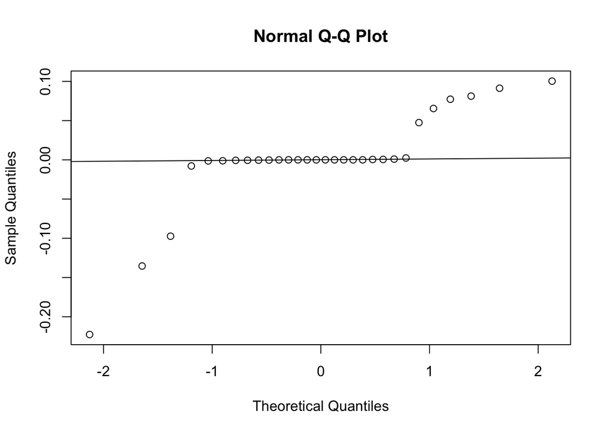

```r
# Check for normality of the random effects
reffects <- unlist(ranef(b))
qqnorm(reffects)
qqline(reffects)
```

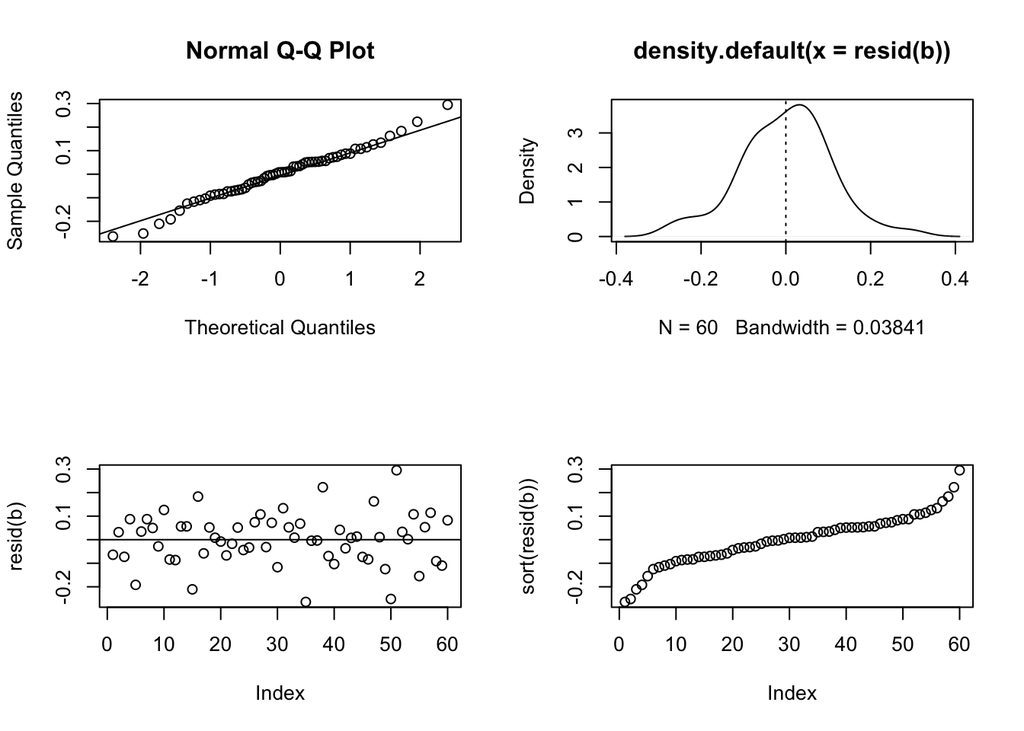

```r
par(mfrow = c(2, 2))
# Check model assumptions:
qqnorm(resid(b))
qqline(resid(b))

plot(density(resid(b)))
abline(v = 0, lty = 3)

# Homoskedasticity
plot(resid(b))
abline(h = 0)
# Outliers
plot(sort(resid(b)))
```

```r
shapiro.test(resid(b))
```

```
##
##  Shapiro-Wilk normality test
##
## data:  resid(b)
## W = 0.98704, p-value = 0.7751
```

### Description of analyses

Take a look at the summary of the fitted model.

```r
summary(b)
```

```
## Linear mixed model fit by REML. t-tests use Satterthwaite's method [
## lmerModLmerTest]
## Formula: A1C ~ 1 + Time + Time_2 + (1 | Patient) + (0 + Time | Patient) +
##     (0 + Time_2 | Patient)
##    Data: a1cq
##
## REML criterion at convergence: -29.8
##
## Scaled residuals:
##      Min       1Q   Median       3Q      Max
## -2.21352 -0.58906  0.06709  0.49672  2.46712
##
## Random effects:
##  Groups    Name        Variance  Std.Dev.
##  Patient   (Intercept) 1.817e-02 0.134790
##  Patient.1 Time        3.943e-06 0.001986
##  Patient.2 Time_2      0.000e+00 0.000000
##  Residual              1.427e-02 0.119461
## Number of obs: 60, groups:  Patient, 10
##
## Fixed effects:
##               Estimate Std. Error         df t value Pr(>|t|)
## (Intercept)  7.731e+00  6.841e-02  2.273e+01 113.013  < 2e-16 ***
## Time         3.779e-02  4.827e-03  4.906e+01   7.828 3.48e-10 ***
## Time_2      -4.526e-04  8.989e-05  4.665e+01  -5.035 7.58e-06 ***
## ---
## Signif. codes:  0 '***' 0.001 '**' 0.01 '*' 0.05 '.' 0.1 ' ' 1
##
## Correlation of Fixed Effects:
##        (Intr) Time
## Time   -0.687
## Time_2  0.608 -0.964
## convergence code: 0
## boundary (singular) fit: see ?isSingular
```

Fitted model:
$$Y_{ij} = a_i + b_iTime_{ij} + c_iTime_{ij}^2 + \epsilon_{ijk}$$
Where $Y_{ij}$ represents the blood sugar level of patient i at time $Time_{ij}$;
$a_i\sim N(7.73, 0.0182)$;
$b_i\sim N(0.0378, 3.94*10^{-6})$;
$c_i\sim N(-4.53 * 10^{-4}, 0)$;
$\epsilon_{ijk} \sim N(0, \sigma_e^2)$.

At the 5% significance level, there was statistically significant association between a1c level and time as well as quadratic time (p < 0.001).

### Conclusion

We were interested in looking at the changes in blood sugar level for some Type II diabetes patients who went through some negative life changes. A random effects model was used to estimate the effect of time on a1c level. A1C was modeled with the fixed effect of time and quadratic time, and random effect of patient. We found that at the 5% significance level, there was statistically significant association between a1c level and time, quadratic time after the negative life changes (p < 0.001).